# The Linear Model

OLS, Inference, and Diagnostics

F. Candau (UPPA-TREE)

2026-06-08

## Where OLS comes from: Gauss and Ceres

- **1801** — Giuseppe Piazzi spots **Ceres** (a dwarf planet in the asteroid belt), then loses it behind the Sun after only a handful of noisy observations.
- **The question:** *where will it reappear?*
- The young **Carl Friedrich Gauss** computes the orbit with a new method — choose the trajectory that **minimises the sum of squared residuals** (the gaps between the observed positions and the predicted ones).
- **Result:** an accurate prediction; Ceres is found again. **Ordinary Least Squares (OLS)** is born.

## OLS in one picture

$$y_i = \beta_0 + \beta_1 x_i + \varepsilon_i$$

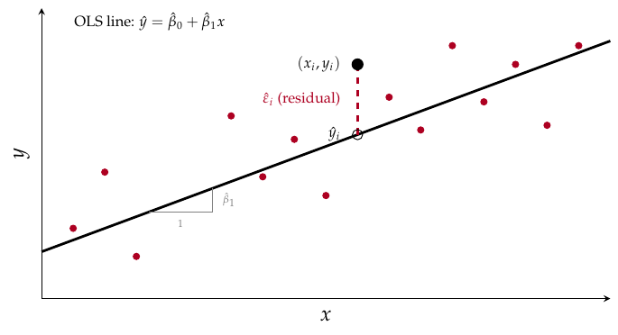

OLS picks $(\hat\beta_0,\hat\beta_1)$ by **least squares** — minimising
$$(\hat\beta_0,\hat\beta_1)=\arg\min_{\beta_0,\beta_1}\
\underbrace{\sum_{i}\big(\underbrace{y_i-\beta_0-\beta_1 x_i}_{\hat\varepsilon_i}\big)^2}_{\text{sum of squared residuals}}.$$

## Solving for $\hat\beta$ (simple regression)

Minimising the sum of squared residuals $S(\beta_0,\beta_1)=\sum_i (y_i-\beta_0-\beta_1 x_i)^2$, set its two derivatives to zero,
$$\sum_i (y_i-\hat\beta_0-\hat\beta_1 x_i)=0, \qquad
\sum_i x_i\,(y_i-\hat\beta_0-\hat\beta_1 x_i)=0.$$

- The first gives $\hat\beta_0=\bar y-\hat\beta_1\bar x$ — the line passes through $(\bar x,\bar y)$.
- Substituting into the second and solving for the slope,
  $$\hat\beta_1=\frac{\sum_i (x_i-\bar x)(y_i-\bar y)}{\sum_i (x_i-\bar x)^2}
  =\frac{\operatorname{Cov}(x,y)}{\operatorname{Var}(x)}.$$

($\bar x=\tfrac1n\sum_i x_i$ is the sample mean; a hat marks an estimate. The $1/n$ in $\operatorname{Cov}$ and $\operatorname{Var}$ cancels, so this ratio of moments equals the ratio of sums above.)

## Multiple regression

$$y_i = \beta_0 + \beta_1 x_{1i} + \dots + \beta_k x_{ki} + \varepsilon_i$$

- Here $k$ is the **number of explanatory variables** (slopes); with the intercept there are $k+1$ coefficients.
- Each $\beta_j$ is the effect of $x_j$ **holding the other regressors fixed** — identified from the variation in $x_j$ *conditional on* the others.
- OLS minimises $\sum_i (y_i - x_i'\beta)^2$, with closed-form solution
  $$\boxed{\;\hat\beta = (X'X)^{-1}X'y\;}$$
  where $X$ is the $n\times(k{+}1)$ matrix of regressors and a **prime** denotes the **transpose** (so $X'$ is $X$ flipped, rows become columns).

## OLS by hand: a worked example

A small case, **3 observations, 2 parameters**, you can check on the board. Model $y=\beta_0+\beta_1 x$ with points $(x,y)=(1,2),(2,2),(3,5)$,
$$X=\begin{pmatrix}1&1\\1&2\\1&3\end{pmatrix},\;\; y=\begin{pmatrix}2\\2\\5\end{pmatrix},\;\;
X'X=\begin{pmatrix}3&6\\6&14\end{pmatrix},\;\; X'y=\begin{pmatrix}9\\21\end{pmatrix}.$$
$$(X'X)^{-1}=\frac{1}{6}\begin{pmatrix}14&-6\\-6&3\end{pmatrix},\qquad
\hat\beta=(X'X)^{-1}X'y=\begin{pmatrix}\hat\beta_0\\\hat\beta_1\end{pmatrix}
=\begin{pmatrix}0\\1.5\end{pmatrix}.$$

- First column of $X$ is **1s** (the intercept); $\det(X'X)=42-36=6$.
- **Check:** $\hat\beta_1=\dfrac{\sum_i(x_i-\bar x)(y_i-\bar y)}{\sum_i(x_i-\bar x)^2}=\dfrac{3}{2}=1.5$, the matrix formula reproduces the simple-regression slope.

## Roadmap

We can already *compute* $\hat\beta$. The rest of the lecture asks four questions.

1. **Interpret** — what does a coefficient *mean*?
2. **Inference** — is it *real* (precise, significant)?
3. **Assumptions, and when they fail** — is it *valid* (unbiased, honest SE)?
4. **Doing it in Python** (pandas + statsmodels).

# Interpreting coefficients

## Interpretation of coefficients

| model | equation | a change in $x$ … | … changes $y$ by |
| --- | --- | --- | --- |
| level–level | $y=\beta_0+\beta_1 x$ | $+1$ unit | $\beta_1$ units |
| log–level | $\ln y=\beta_0+\beta_1 x$ | $+1$ unit | $100\,(e^{\beta_1}-1)\,\%$ |
| level–log | $y=\beta_0+\beta_1\ln x$ | $+1\%$ | $\beta_1/100$ units |
| log–log | $\ln y=\beta_0+\beta_1\ln x$ | $+1\%$ | $\beta_1\,\%$ (elasticity) |

For small $\beta_1$ these collapse to the familiar approximations (e.g. log–level $\approx 100\beta_1\%$); the exact forms matter only when $\beta_1$ is sizeable.

## Example: the gender wage gap

$$\ln(\text{wage}_i) = \beta_0 + \beta_1\,\text{woman}_i + \varepsilon_i, \qquad
\hat\beta_1 \approx -0.285.$$

Women earn on average $\approx \mathbf{24.8\%}$ less than men (INSEE, 2017). For a log outcome with a **dummy** regressor, use the exact effect,
$$e^{\hat\beta_1}-1 = e^{-0.285}-1 = -0.248 = -24.8\%.$$

## Ceteris paribus

Add controls, education, experience, hours, occupation, sector,
$$\ln(\text{wage}_i)=\beta_0+\beta_1\,\text{woman}_i+\beta_2\,\text{educ}_i+\dots+\varepsilon_i,
\qquad \hat\beta_1\approx -0.10.$$

- **“All else equal,”** women earn $\approx \mathbf{9.5\%}$ less, exactly $e^{-0.10}-1=-0.095$. The gap shrinks once we hold **observables** fixed, but only the *observed* ones.
- **Careful, not every control helps.** A variable that is itself a *consequence* of being a woman (occupation, sector, if discrimination channels women into lower-paid roles) is a **bad control**: adding it can *hide* part of the true gap. Which controls to include is already a causal question.

**What’s left to check**

We have read these coefficients at face value. Two questions remain. Are they statistically distinguishable from zero (**inference**, next), and are they unbiased in the first place (**assumptions**, after)?

# Inference

## The true $\beta$ we never observe

- Behind the data is a **population** (a data-generating process) with a **true but unknown** coefficient $\beta$ — the effect of $x$ on $y$ for *everyone*. We never see it.
- From **one sample** of $n$ units we compute an **estimate** $\hat\beta$. A *different* sample would give a *different* $\hat\beta$, so $\hat\beta$ is **random**, with a **sampling distribution**.

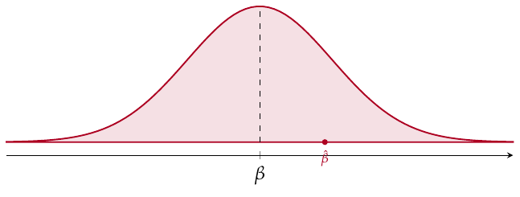

One sample gives one draw $\hat\beta$ from this curve. **Inference** asks how far it is likely to land from the true $\beta$. The curve is drawn centred at $\beta$, that OLS is unbiased is the next slide.

## How precise is $\hat\beta$? The standard error

- OLS is **unbiased** (and **consistent**): across samples $\hat\beta$ is centred on the truth, $\mathbb{E}(\hat\beta)=\beta$.
- The **standard error** is the **standard-deviation spread** of that curve, $\widehat{\text{se}}(\hat\beta)=\sqrt{\widehat{\operatorname{Var}}(\hat\beta)}$, how far a typical $\hat\beta$ lands from $\beta$.
- In simple regression $\operatorname{Var}(\hat\beta_1)=\dfrac{\sigma^2}{\sum_i (x_i-\bar x)^2}$, with $\sigma^2=\operatorname{Var}(\varepsilon_i)$ the error variance (estimated by $\hat\sigma^2=\text{RSS}/(n-k-1)$, with RSS the **residual sum of squares** $\sum_i\hat\varepsilon_i^2$). So the SE is **smaller** when $n$ is large, the regressor varies more, or residuals are tight.

$n-k-1$ is the **degrees of freedom**, we “use up” $k{+}1$ observations estimating the coefficients. This is the *classical* SE (valid under homoskedasticity); we will see it can be wrong, and how to fix it (robust SE).

## Student’s $t$: a story

- W. S. **Gosset**, a chemist at **Guinness**, needed to compare beer batches from **small samples**, and published under the pen-name *“Student”*.
- His **$t$-distribution** describes the estimator’s behaviour when $\sigma^2$ is itself estimated and $n$ is small, exactly our situation.
- *Hold your beer*, it is the workhorse of significance testing.

## The $t$-statistic: $\hat\beta$ in standard-error units

To test $H_0:\beta_k=\beta_k^0$ (usually $\beta_k^0=0$), how far is $\hat\beta_k$ from the hypothesised value, **measured in standard errors**?
$$t=\frac{\hat\beta_k-\beta_k^0}{\widehat{\text{se}}(\hat\beta_k)}
\;\xrightarrow{\;H_0:\beta_k=0\;}\; \frac{\hat\beta_k}{\widehat{\text{se}}(\hat\beta_k)}.$$

- So $t$ is the estimate in **se units**. $t=2$ means $\hat\beta_k$ sits two standard errors from $0$. A **large $|t|$** means $\hat\beta_k$ is far from $0$ relative to its noise, implausible if the true $\beta_k$ were $0$.
- Under the assumptions (normal errors), $t$ follows **Student’s $t$ with $n-k-1$ degrees of freedom**, which $\to \mathcal N(0,1)$ as $n$ grows.
- **Why $t$, not the normal?** Because we *estimate* $\sigma^2$ inside $\widehat{\text{se}}$; that extra uncertainty **fattens the tails** in small samples.

## Reading the $t$: critical values and rejection

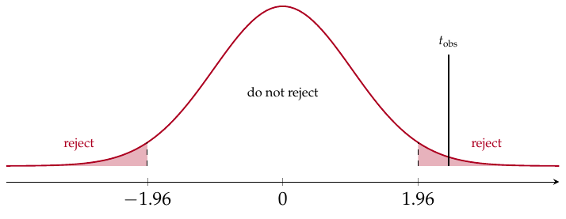

- Under $H_0$, $t$ is centred at $0$. **Reject** $H_0$ when $t$ lands in the **tails**, beyond the **critical value**.
- Two-sided $5\%$: reject if $|t|>1.96$ (shaded $2.5\%+2.5\%$). Other levels, $10\%\to 1.645$, $1\%\to 2.58$.
- **Rule of thumb:** $|\hat\beta_k|>2\,\widehat{\text{se}}$ means significant at $5\%$. The $p$-value, next, is the tail area beyond the observed $|t|$.

## $p$-values and confidence intervals

**What a p-value is, and is not**

The $p$-value is the probability, **if $H_0$ were true**, of a $|t|$ at least as large as the one observed. A small $p$ means the data are unlikely under $H_0$, so we reject.

It is **not** the probability that $H_0$ is true.

- **95% confidence interval:** $\hat\beta_k\pm 1.96\,\widehat{\text{se}}(\hat\beta_k)$. If it **excludes 0**, reject $H_0$ at $5\%$ (equivalent to the $t$-test).
- **But significance is not effect size**, and insignificance is not “no effect”, see the next slide.

## Significance is not effect size: power and magnitude

**Power, the chance of catching a true effect**

The **power** of a test is the probability it rejects $H_0$ *when $H_0$ is false*, that is, detects a real effect. It **rises** with the sample size $n$, the size of the true effect, and precision (small SE).

- **Small $n$ means low power.** A real, theory-backed effect can look **insignificant** only because the SE is large. *Absence of evidence is not evidence of absence*, get **more data**, do not drop the variable.
- **Large $n$ means almost everything rejects $H_0$.** Even economically trivial effects become “significant.”

**Judge the magnitude concretely.** Convert $\hat\beta$ to real units (via the functional form), compare it to a **benchmark** (the mean or SD of $y$, a policy threshold, other studies), and read the **whole CI**, a wide interval is *uninformative*, not *zero*.

## Reading the whole output: $R^2$ and the $F$-test

**R-squared, goodness of fit**

Total variation in $y$ splits into explained and residual parts,
$$\sum_i(y_i-\bar y)^2=\sum_i(\hat y_i-\bar y)^2+\sum_i\hat\varepsilon_i^2,$$
the *total* (TSS), *explained* (ESS) and *residual* (RSS) sum of squares. Then $R^2=\dfrac{\text{ESS}}{\text{TSS}}=1-\dfrac{\text{RSS}}{\text{TSS}}\in[0,1]$, the share of $y$’s variance the model explains.

- **High $R^2 \neq$ good estimate.** A biased $\hat\beta$ can fit well, and a valid causal effect can have low $R^2$. *Fit $\neq$ correctness* (adjusted $R^2$ penalises extra regressors).
- **The $F$-test** checks **joint** significance ($H_0$, several slopes $=0$ at once), also printed in every output. Handy under multicollinearity, individual $t$’s look insignificant, yet the joint $F$ is significant.

# The assumptions, and when they fail

## The OLS assumptions (Gauss–Markov)

1. **Linearity in parameters,** $y = X\beta + \varepsilon$.
2. **Exogeneity (zero conditional mean),** $\mathbb{E}(\varepsilon_i \mid X)=0$.
3. **Homoskedasticity,** $\operatorname{Var}(\varepsilon_i\mid X)=\sigma^2$ (constant).
4. **No autocorrelation,** $\operatorname{Cov}(\varepsilon_i,\varepsilon_j\mid X)=0$, $i\neq j$.
5. **No perfect multicollinearity,** needed for $(X'X)^{-1}$ to exist.

(Normality of the errors is added *only* for exact small-sample $t$-tests.) Here $\mathbb{E}[\,\cdot\mid X]$ is the **expectation** given the regressors.

**What each assumption buys**

**1–2** give OLS **unbiased and consistent**. Adding **3–4** make it **BLUE** (minimum variance among linear unbiased estimators). Each “when it fails” slide drops one and asks what breaks.

## Heteroskedasticity: a variance problem

Heteroskedasticity is always a problem with the **variance (volatility)** of the forecast errors.

- **Cross-section,** the error variance varies with the explanatory variable $x_i$.
- **Time series,** the error variance varies with the explanatory variable $x_t$.
- **Spatial (cross-sectional) form,** the error *variance* differs systematically across places, e.g. larger in some regions than others. Variance, not correlation, error correlation across units is autocorrelation, next.
- **Another time-series form,** the error variance at $t$ varies with the variance of *past* errors.

## Homoskedasticity vs. heteroskedasticity

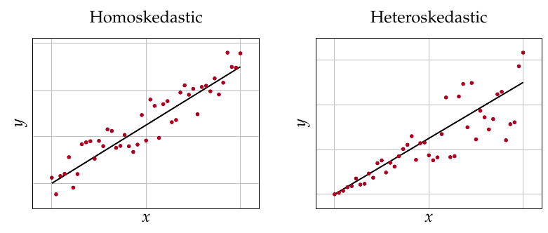

Left, residual spread is roughly **constant**. Right, it **fans out** with $x$. Beware, correlated errors can look similar, so rely on **formal tests**, not the eye.

## Heteroskedasticity: detection

$\operatorname{Var}(\varepsilon_i\mid X)$ is **not** constant. Then OLS is still **unbiased** but no longer efficient, and **default standard errors are wrong**, giving invalid $t$-tests.

**Tests, H0 is homoskedasticity**

**Breusch–Pagan**, regress $\hat\varepsilon_i^2$ on the regressors, $\hat\varepsilon_i^2=\delta_0+\delta_1 x_{1i}+\dots+v_i$, and test $\delta_1=\dots=0$.

**White**, same idea, adding *squares* and *interactions*.

$p<0.05$ rejects homoskedasticity. ($\hat\varepsilon_i=y_i-x_i'\hat\beta$ are the **residuals**, the estimated errors.)

## Heteroskedasticity: the fix

**Use robust standard errors by default**

Heteroskedasticity-consistent (**HC** / White) standard errors fix inference without changing $\hat\beta$.

- The **sandwich** covariance (White, 1980),
  $$\widehat{\operatorname{Var}}(\hat\beta)=(X'X)^{-1}\,X'\operatorname{diag}(\hat\varepsilon_i^2)\,X\,(X'X)^{-1},$$
  where $\operatorname{diag}(\hat\varepsilon_i^2)$ is the diagonal matrix of squared residuals.
- **$\hat\beta$ is unchanged**, only the SE (hence $t$, $p$, CIs) are corrected.
- The form shown is **HC0**; finite-sample versions inflate the squared residuals, **`HC3`** is the recommended default.
- Alternative, **GLS / FGLS** model the variance explicitly (less common in practice).

## Autocorrelation: an error-correlation problem

Autocorrelation is no longer about the *variance* of the error, but about the **error itself being correlated** across observations.

- **Cross-section,** one unit’s errors affect another’s, when units share common characteristics or factors that create dependence. *Example, spatial data.*
- **Time series,** the error at $t$ is a function of past errors ($t-1, t-2, \dots$).

## Autocorrelation: tests and fix

Formally, $\operatorname{Cov}(\varepsilon_i,\varepsilon_j)\neq 0$,

- **spatial,** $\varepsilon_i=\rho\sum_{j\neq i} w_{ij}\varepsilon_j+u_i$ ($w_{ij}$ a proximity weight);
- **time series,** $\varepsilon_t=\rho_1\varepsilon_{t-1}+\dots+\rho_p\varepsilon_{t-p}+u_t$.

OLS stays unbiased, but **standard errors are wrong**.

- **Tests,** Durbin–Watson ($DW\approx 2$ none, $\approx 0$ positive, $\approx 4$ negative, but invalid with a lagged dependent variable); Breusch–Godfrey (higher-order, valid with lagged $y$).
- **Fix,** **HAC** SE (Newey–West, 1987), robust to *both* heteroskedasticity and autocorrelation; or Cochrane–Orcutt / Prais–Winsten.

## Multicollinearity

Two or more regressors are strongly linearly related, e.g. $x_1\approx a+b\,x_2$,
$$y=\beta_0+\beta_1 x_1+\beta_2 x_2+\varepsilon.$$

- Consequences, **unstable** coefficients (signs flip), **inflated** standard errors and wide CIs, hard to separate individual effects. ($\hat\beta$ stays unbiased.)
- **Detect** with the variance inflation factor (VIF). **Fix** by dropping or combining variables, or getting more data.
- *Example*, regressing salary on **age and experience**, highly correlated, so $\beta_1,\beta_2$ are hard to pin down.

## Non-normality of residuals

- Normal errors are needed for **exact small-sample** $t$-tests, **not** for unbiasedness, and not asymptotically (the CLT rescues large $n$).
- **Test** with Jarque–Bera ($H_0$, residuals are normal); $p<0.05$ rejects.
- If violated **and** $n$ small, use the **bootstrap**, resample the data with replacement many times to approximate the sampling distribution of $\hat\beta$.

## Endogeneity: the deepest problem

When $\mathbb{E}(\varepsilon\mid X)\neq 0$, OLS is **biased**, and no robust SE can fix that. Three sources, **omitted variables**, **reverse causality**, **measurement error**.

**Which way does omitted-variable bias go?** Its sign is (effect of the omitted variable on $y$) $\times$ (its correlation with $x$). *Wage gap*, education and ability raise wages and correlate with the woman dummy in the raw data, biasing the uncontrolled gap, and adding controls moved $-0.285\to-0.10$.

**Causal inference, the rest of the course**

Designed to defeat the first two. Four workhorses, randomized experiments, **difference-in-differences**, regression discontinuity, and **instrumental variables** (later, shift-share).

# Estimating in Python

## The toolkit: which package, for what

| package | use it for |
| --- | --- |
| `pandas` | load, inspect, clean, merge, transform data (the `DataFrame`) |
| `numpy` | numerical operations (logs, powers, arrays) |
| `statsmodels` | **estimation + inference** (coef, se, $t$, $p$, CI) and **diagnostic tests** |
| `matplotlib` | plots and visual checks |

Typical workflow, **load, inspect, transform, estimate, robust SE, diagnostics.** (Fixed effects and IV come later, with `pyfixest`.)

## Load and inspect (pandas)

```python
import pandas as pd

df = pd.read_stata("wage.dta")        # or read_csv / read_excel
df.head(); df.describe(); df.info()   # inspect first!
df = pd.merge(df, dr, on="id", how="inner")
```

- **Always inspect before estimating**, types, ranges, missing values, oddities.
- `merge`, `inner` keeps matched rows, `outer` keeps all (gaps become `NaN`), `left`/`right` keep one side. Windows paths, prefix with `r"..."`.

## Transform variables (pandas + numpy)

```python
import numpy as np

df["lwage"]  = np.log(df["wage"])     # logs via numpy
df["exper2"] = df["exper"]**2         # quadratic term
```

- For **dummies and categoricals**, do not recode by hand, let the formula do it with `C(...)`, e.g. `C(sector)` expands a category into dummies (one level kept as baseline).

## Estimate and read the output (statsmodels)

```python
import statsmodels.formula.api as smf

f = "lwage ~ woman + educ + exper"
m = smf.ols(f, df).fit()
print(m.summary())     # coef, se, t, p-value, 95% CI
```

- Formula syntax, `~` splits $y$ from the regressors; `x1*x2` adds both terms **and** their interaction; `C(g)` makes dummies.
- Each summary row is exactly what we covered, $\hat\beta$, its se, the $t$-stat, the $p$-value, and the 95% CI.

## Best practice: robust standard errors by default

```python
# reuse the formula f from the previous slide
m = smf.ols(f, df).fit(cov_type="HC3")   # robust SE
m = smf.ols("y ~ x", df).fit(cov_type="HAC",
            cov_kwds={"maxlags": 4})     # time series
```

- `cov_type="HC3"` leaves $\hat\beta$ unchanged and corrects se, $t$, $p$, CI, make it your **default** in cross-sections.
- For time series use **HAC** (Newey–West), set `maxlags` from the data frequency.

## Diagnostics, when you need them (statsmodels.stats)

```python
from statsmodels.stats import diagnostic as smd
from statsmodels.stats.stattools import jarque_bera

_, p_white, _, _ = smd.het_white(m.resid, m.model.exog)
_, p_bp, _, _    = smd.het_breuschpagan(m.resid, m.model.exog)
jb, p_jb, *_     = jarque_bera(m.resid)            # normality
```

- With robust SE already the default, you test mainly to **understand** the data, and to decide whether time-series data need **HAC**. A small $p$ flags the problem.
- **Do not test-then-switch**, pre-testing distorts inference; defaulting to robust SE avoids it. (`het_white` can fail with many regressors, fall back to Breusch–Pagan.)

## Reference

The single text for this course, read it for the full, detailed bibliography behind everything in these slides.

Wooldridge, Jeffrey M. 2025. *Introductory Econometrics: A Modern Approach*. 8th ed. Cengage Learning.